# Introduction to R programming for data science Day 5 exercises

Dr. Francesca Finotello

Medical University of Innsbruck, Austria

# Plots

## Ex. 5.1

Load the *iris* dataset (also used for day-4 exercises):

```r
data("iris")
head(iris)
```

```
##   Sepal.Length Sepal.Width Petal.Length Petal.Width Species
## 1          5.1         3.5          1.4         0.2  setosa
## 2          4.9         3.0          1.4         0.2  setosa
## 3          4.7         3.2          1.3         0.2  setosa
## 4          4.6         3.1          1.5         0.2  setosa
## 5          5.0         3.6          1.4         0.2  setosa
## 6          5.4         3.9          1.7         0.4  setosa
```

Extract a portion of the dataset corresponding to the Iris virginica species and save it into a new data.frame called *iris.virginica*.

```r
iris.virginica <- iris[iris[,"Species"]=="virginica",]
```

Using the *iris.virginica* data.frame, make a scatterplot of sepal length (y-axis) versus petal length (x-axis).

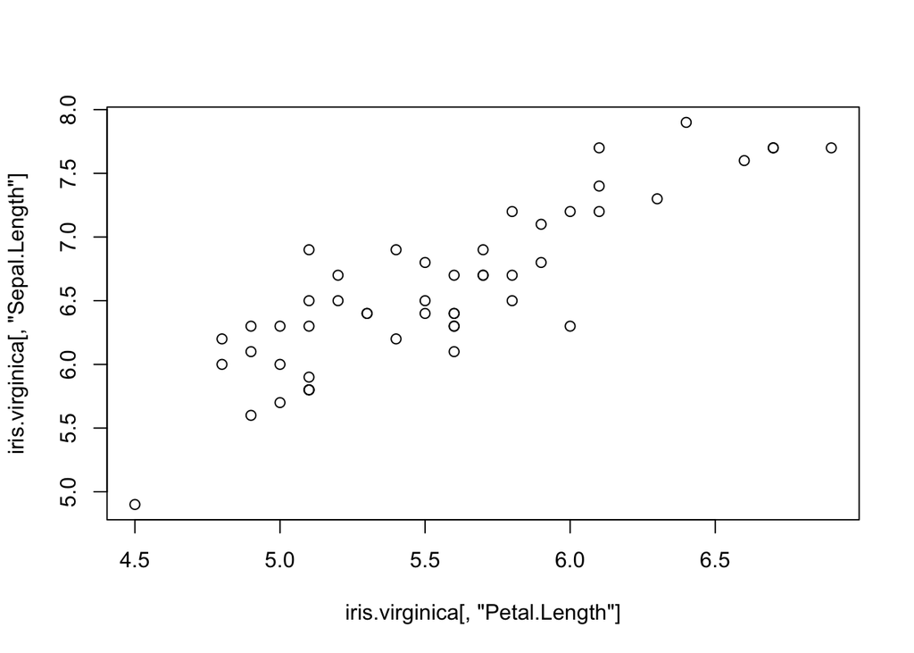

```r
plot(iris.virginica[,"Petal.Length"],
     iris.virginica[,"Sepal.Length"])
```

Add title, x- and y-axis labels.

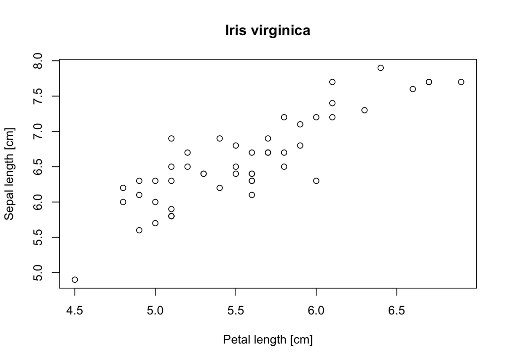

```r
plot(iris.virginica[,"Petal.Length"],
     iris.virginica[,"Sepal.Length"],
     main = "Iris virginica",
     xlab = "Petal length [cm]",
     ylab = "Sepal length [cm]")
```

Fix their magnification with *cex.main*, *cex.axis*, and *cex.lab*.

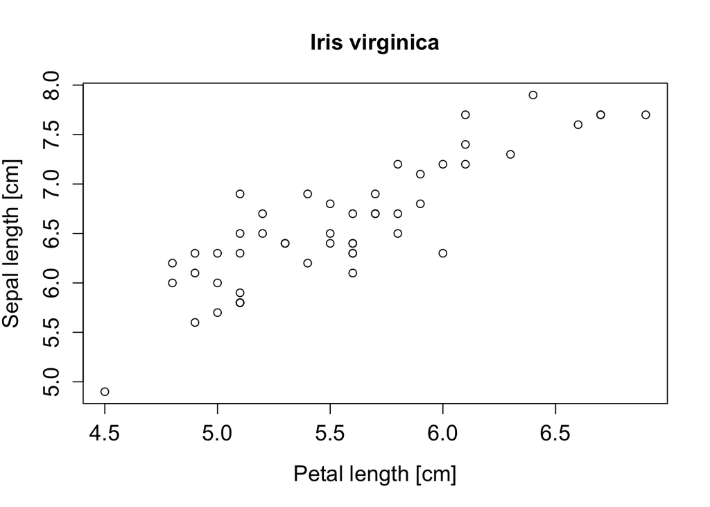

```r
plot(iris.virginica[,"Petal.Length"],
     iris.virginica[,"Sepal.Length"],
     main = "Iris virginica",
     xlab ="Petal length [cm]",
     ylab = "Sepal length [cm]",
     cex.main = 1.3,
     cex.lab = 1.3,
     cex.axis = 1.3)
```

Change the orientation of all axis labels to horizontal using the *las* function (use the *help* function to understand its usage).

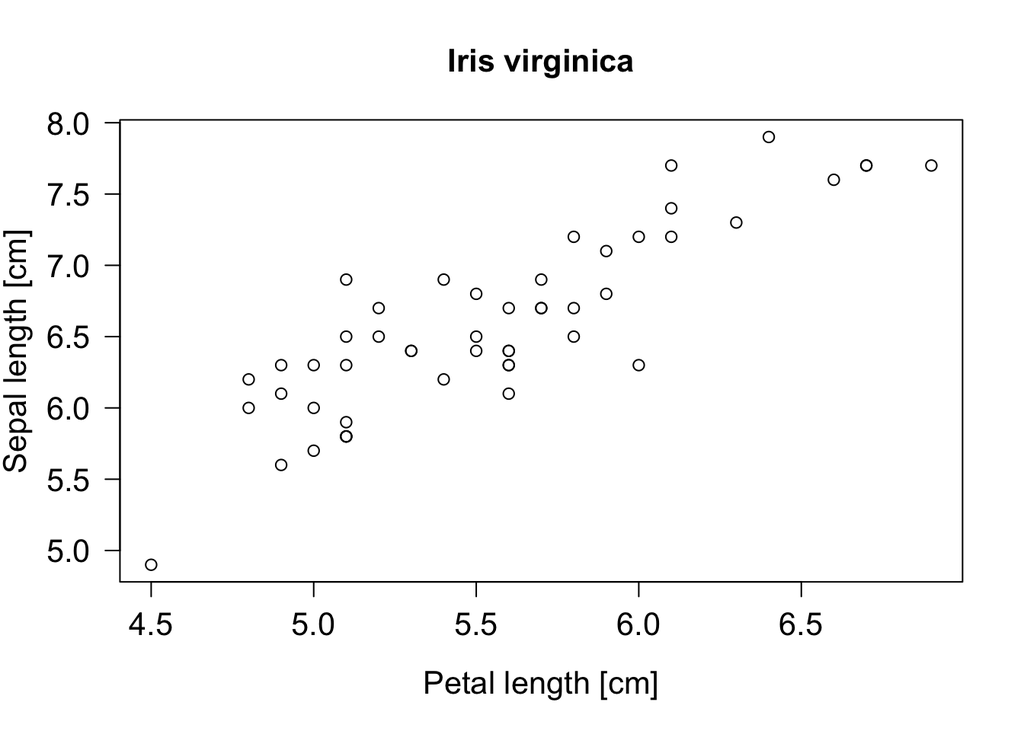

```r
plot(iris.virginica[,"Petal.Length"],
     iris.virginica[,"Sepal.Length"],
     main = "Iris virginica",
     xlab ="Petal length [cm]",
     ylab = "Sepal length [cm]",
     cex.main = 1.3,
     cex.lab = 1.3,
     cex.axis = 1.3,
     las = 1)
```

Change the character used to show the data point to have a filled circle.

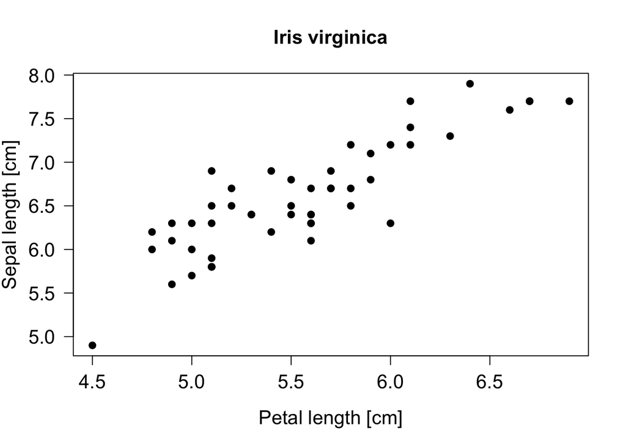

```r
plot(iris.virginica[,"Petal.Length"],
     iris.virginica[,"Sepal.Length"],
     main = "Iris virginica",
     xlab ="Petal length [cm]",
     ylab = "Sepal length [cm]",
     cex.main = 1.3,
     cex.lab = 1.3,
     cex.axis = 1.3,
     las = 1,
     pch = 19)
```

Use a “color-picker” or “color-palette” website (e.g., https://colorbrewer2.org) to select a color you like and obtain its HEX code (e.g., “#004643”), and use it to specify the color of the points.

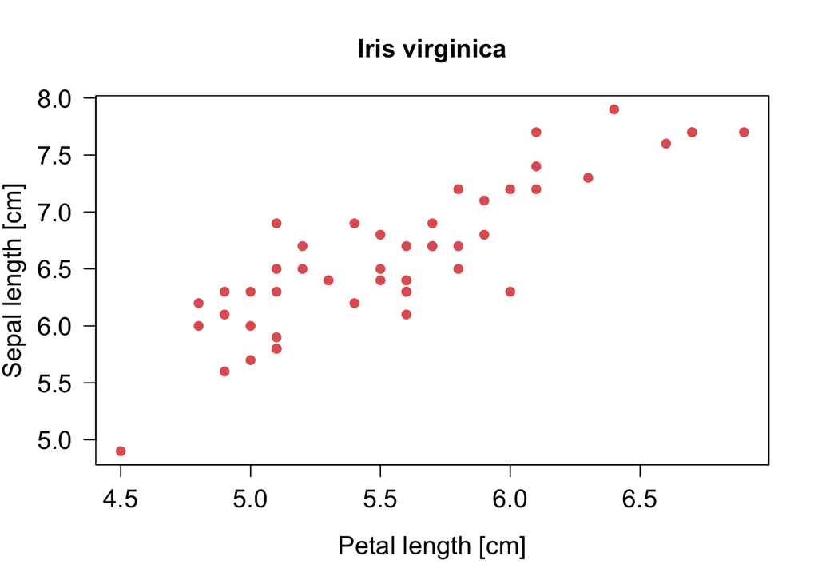

```r
plot(iris.virginica[,"Petal.Length"],
     iris.virginica[,"Sepal.Length"],
     main = "Iris virginica",
     xlab ="Petal length [cm]",
     ylab = "Sepal length [cm]",
     cex.main = 1.3,
     cex.lab = 1.3,
     cex.axis = 1.3,
     las = 1,
     pch = 19,
     col = "#e16162")
```

Compute the linear fit of sepal length vs. petal length and save it into a variable called *vFit*.

```r
vFit <- lm(Sepal.Length~Petal.Length,
           data=iris.virginica)
```

Plot the linear fit using the *abline* function, using a thin (`lwd = 0.8`), dashed, dark-gray line.

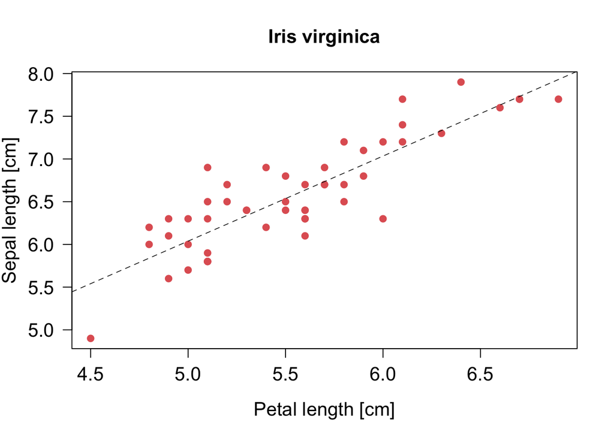

```r
plot(iris.virginica[,"Petal.Length"],
     iris.virginica[,"Sepal.Length"],
     main = "Iris virginica",
     xlab ="Petal length [cm]",
     ylab = "Sepal length [cm]",
     cex.main = 1.3,
     cex.lab = 1.3,
     cex.axis = 1.3,
     las = 1,
     pch = 19,
     col = "#e16162")

abline(vFit,
       col = "gray4",
       lty = 2,
       lwd = 0.8)
```

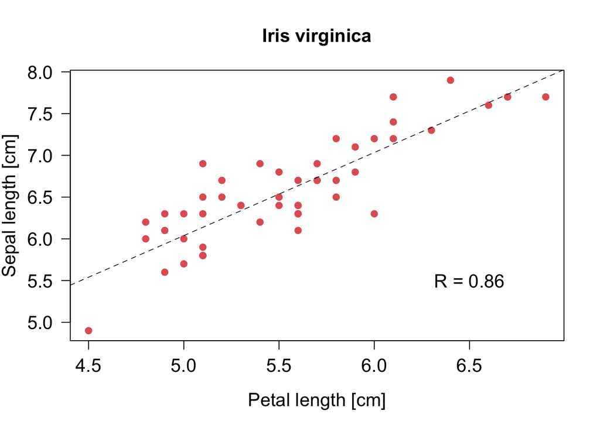

```r
plot(iris.virginica[,"Petal.Length"],
     iris.virginica[,"Sepal.Length"],
     main = "Iris virginica",
     xlab ="Petal length [cm]",
     ylab = "Sepal length [cm]",
     cex.main = 1.3,
     cex.lab = 1.3,
     cex.axis = 1.3,
     las = 1,
     pch = 19,
     col = "#e16162")

abline(vFit,
       col = "gray4",
       lty = 2,
       lwd = 0.8)

R <- round(cor(iris.virginica[,"Petal.Length"],
                iris.virginica[,"Sepal.Length"]), 2)
text(x = 6.5, y = 5.5,
     labels = paste0("R = ", R),
     cex = 1.3)
```

## Ex. 5.2

From the *iris* dataset, extract the data corresponding to the Iris versicolor species and save it into a new data.frame called *iris.versicolor*.

```r
iris.versicolor <- iris[iris[,"Species"]=="versicolor",]
```

Using the *iris.versicolor* data.frame you have just created, make an density histogram of petal length.

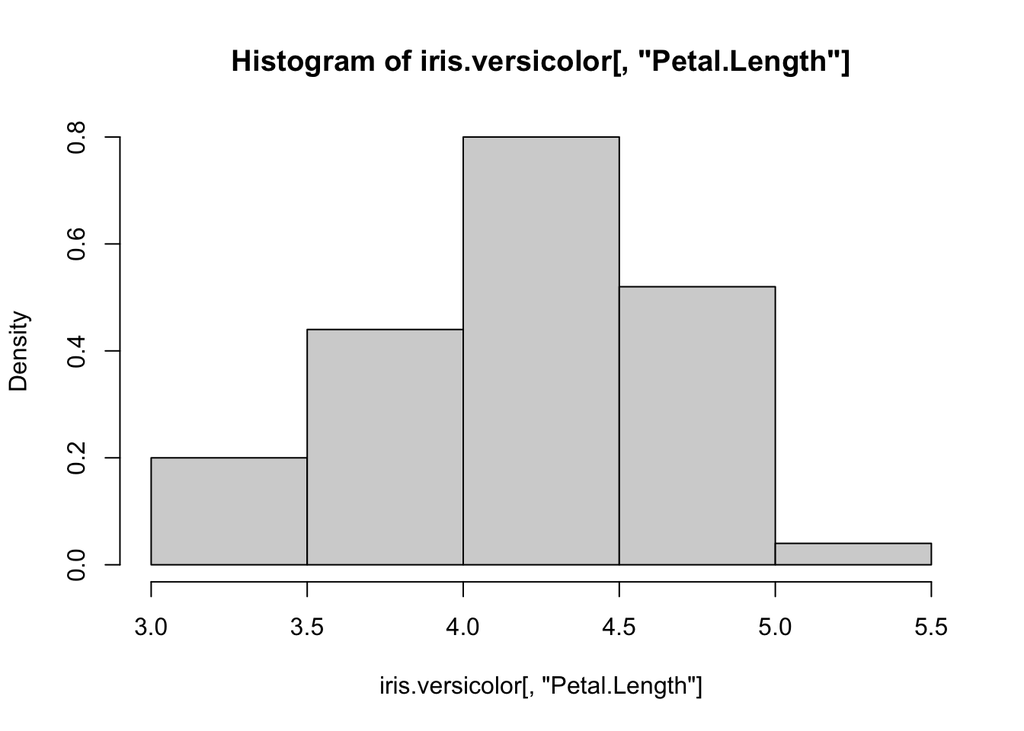

```r
hist(iris.versicolor[,"Petal.Length"],
     freq = FALSE)
```

Add title and x-axis names with magnification 1.2.

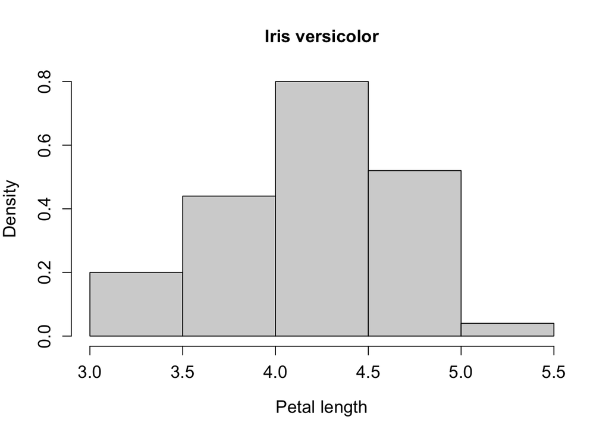

```r
hist(iris.versicolor[,"Petal.Length"],
     freq = FALSE,
     main = "Iris versicolor",
     xlab = "Petal length",
     cex.lab = 1.2,
     cex.axis = 1.2,
     cex.main = 1.2)
```

Change the color of the bars to *lightblue*.

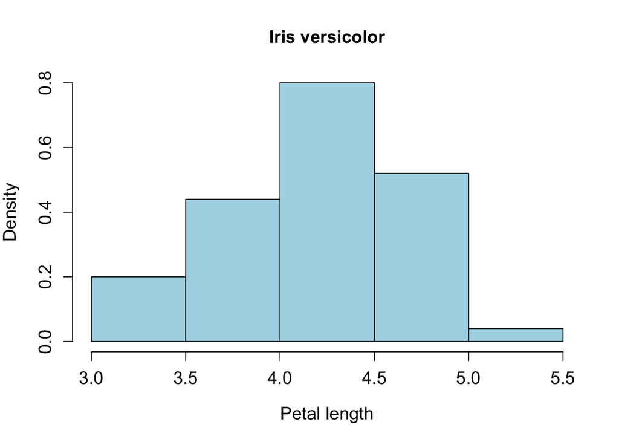

```r
hist(iris.versicolor[,"Petal.Length"],
     freq = FALSE,
     main = "Iris versicolor",
     xlab = "Petal length",
     cex.lab = 1.2,
     cex.axis = 1.2,
     cex.main = 1.2,
     col = "lightblue")
```

Add a black line with with of 2 representing the density (estimated with the *density* function).

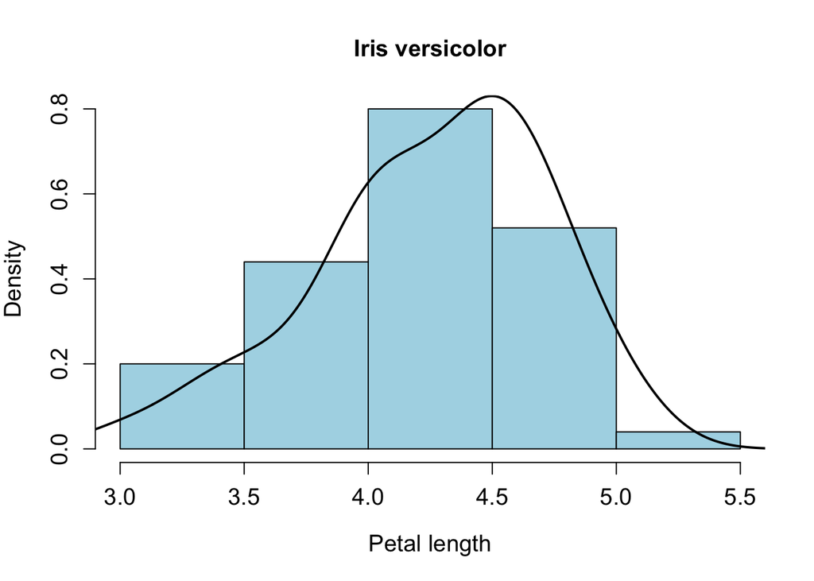

```r
hist(iris.versicolor[,"Petal.Length"],
     freq = FALSE,
     main = "Iris versicolor",
     xlab = "Petal length",
     cex.lab = 1.2,
     cex.axis = 1.2,
     cex.main = 1.2,
     col = "lightblue")

lines(density(iris.versicolor[,"Petal.Length"]),
      col = "black",
      lwd = 2)
```

## Ex. 5.3

From the *iris* dataset, extract the data corresponding to the Iris setosa species and save it into a new data.frame called *iris.setosa*.

```r
iris.setosa <- iris[iris[,"Species"]=="setosa",]
```

Using the three sub-datasets you have created, make a boxplot showing the distribution of petal length for the three species. To do so, put them in a named list to be passed to the *boxplot* function.

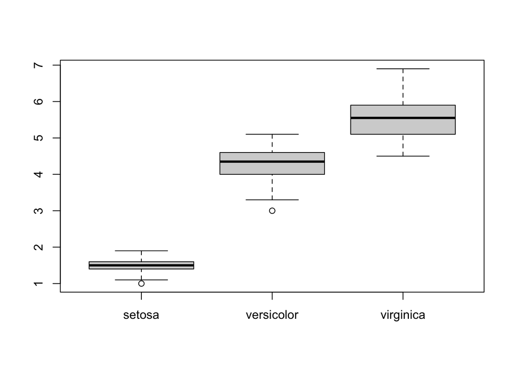

```r
iris.list <- list(setosa = iris.setosa[,"Petal.Length"],
                  versicolor = iris.versicolor[,"Petal.Length"],
                  virginica = iris.virginica[,"Petal.Length"])
boxplot(iris.list)
```

Add title and axis names.

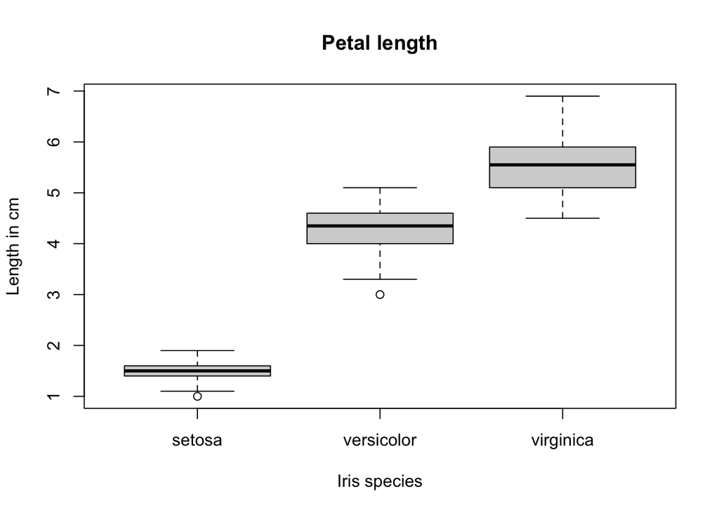

```r
boxplot(iris.list,
        main = "Petal length",
        xlab = "Iris species",
        ylab = "Length in cm")
```

Color the three boxes using a different color for each species.

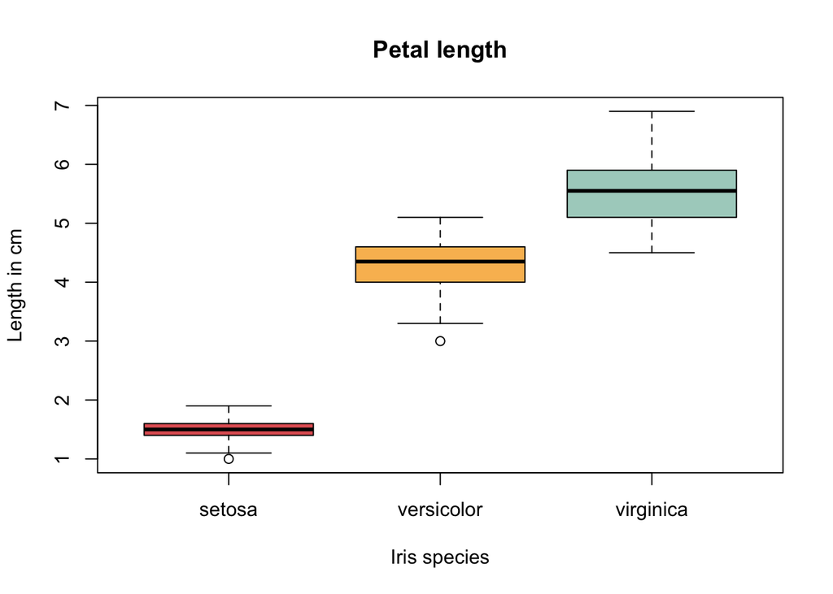

```r
boxplot(iris.list,
        main = "Petal length",
        xlab = "Iris species",
        ylab = "Length in cm",
        col = c("#e16162", "#f9bc60", "#abd1c6"))
```

## Ex. 5.4

The *boxplot* function can be also applied to a data.frame by specifying a *formula* (e.g., `Petal.Width~Species` to consider petal width depending on the species) and *data* (i.e., the `iris` data.frame, in our case). Seek for more information using the *help* function.

Starting from the **original** *iris* data.frame, compute a boxplot of petal width using a formula and color it by using different colors for different species.

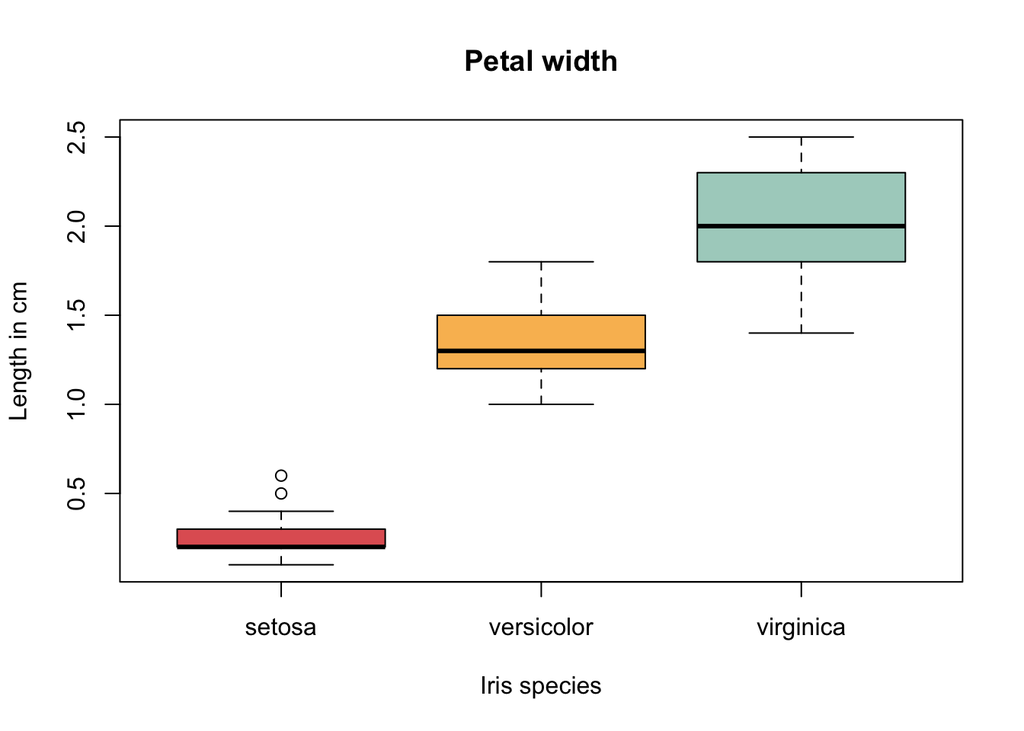

```r
boxplot(Petal.Width~Species,
        data = iris,
        main = "Petal width",
        xlab = "Iris species",
        ylab = "Length in cm",
        col = c("#e16162", "#f9bc60", "#abd1c6"))
```

## Ex. 5.5

Starting from the **original** *iris* data.frame, add a column called *color* reporting the color assigned to each flower (i.e., row) depending on the species it belongs to.

```r
palette <- c("#e16162", "#f9bc60", "#abd1c6")
iris[,"color"] <- NA
iris[iris[,"Species"]=="setosa","color"] <- palette[1]
iris[iris[,"Species"]=="versicolor","color"] <- palette[2]
iris[iris[,"Species"]=="virginica","color"] <- palette[3]
```

Make a scatterplot of sepal length (y-axis) versus petal length (x-axis) of all flowers, colored according to the information saved in the *color* column.

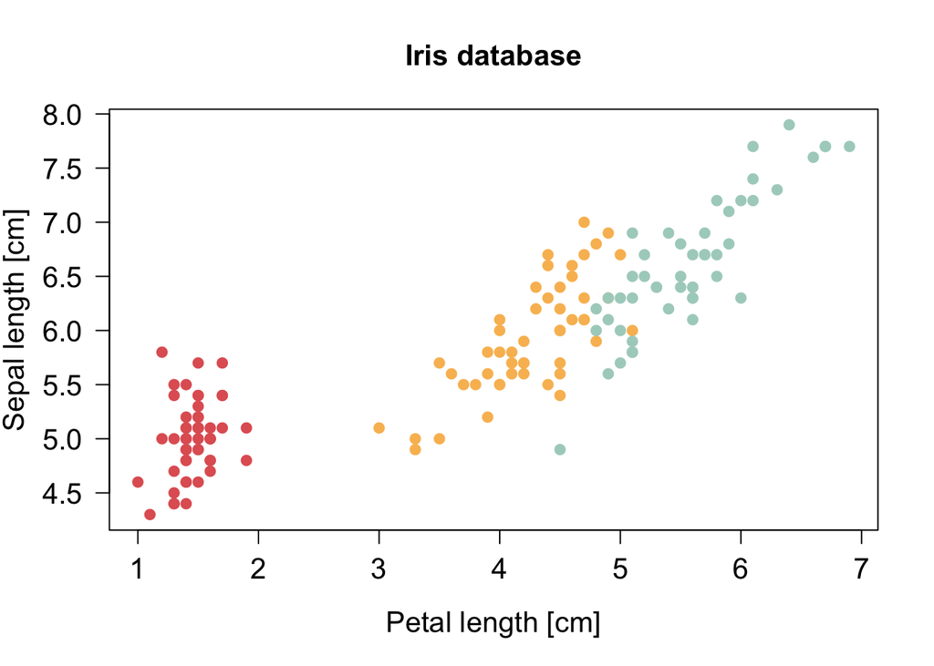

```r
plot(iris[,"Petal.Length"],
     iris[,"Sepal.Length"],
     main = "Iris database",
     xlab ="Petal length [cm]",
     ylab = "Sepal length [cm]",
     cex.main = 1.3,
     cex.lab = 1.3,
     cex.axis = 1.3,
     las = 1,
     pch = 19,
     col = iris[,"color"])
```

Add a line depicting the linear fit and some textual information on the correlation between x and y variables.

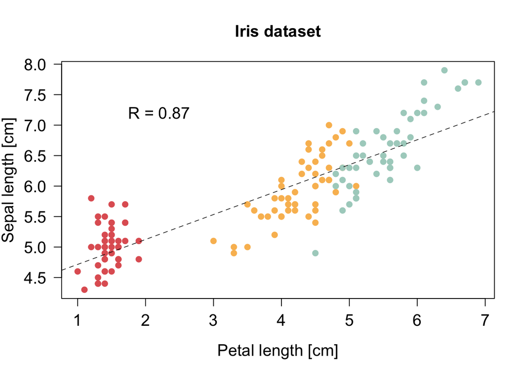

```r
plot(iris[,"Petal.Length"],
     iris[,"Sepal.Length"],
     main = "Iris dataset",
     xlab ="Petal length [cm]",
     ylab = "Sepal length [cm]",
     cex.main = 1.3,
     cex.lab = 1.3,
     cex.axis = 1.3,
     las = 1,
     pch = 19,
     col = iris[,"color"])

vFit2 <- lm(Sepal.Length~Petal.Length,
           data=iris)
abline(vFit2,
       col = "gray4",
       lty = 2,
       lwd = 0.8)

R <- round(cor(iris[,"Petal.Length"],
               iris[,"Sepal.Length"]), 2)
text(x = 2.2, y = 7.2,
     labels = paste0("R = ", R),
     cex = 1.3)
```

You can add a legend to the right of the figure using the *legend* function as in the example below:

```r
legend("bottomright",
     pch = 1,
     bty = "o",
     col = c("red", "green", "blue"),
     legend = c("classA", "classB", "classC"))
```

Modify the arguments of the example above to add an explanatory legend to your figure.

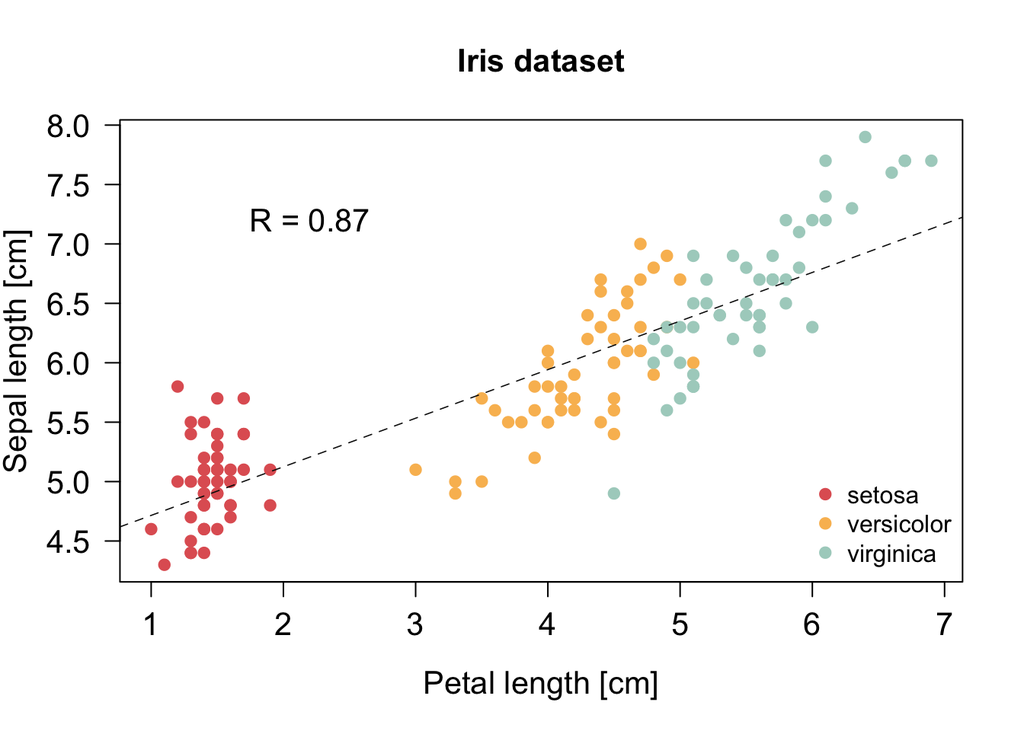

```r
plot(iris[,"Petal.Length"],
     iris[,"Sepal.Length"],
     main = "Iris dataset",
     xlab ="Petal length [cm]",
     ylab = "Sepal length [cm]",
     cex.main = 1.3,
     cex.lab = 1.3,
     cex.axis = 1.3,
     las = 1,
     pch = 19,
     col = iris[,"color"])

vFit2 <- lm(Sepal.Length~Petal.Length,
           data=iris)
abline(vFit2,
       col = "gray4",
       lty = 2,
       lwd = 0.8)

R <- round(cor(iris[,"Petal.Length"],
               iris[,"Sepal.Length"]), 2)
text(x = 2.2, y = 7.2,
     labels = paste0("R = ", R),
     cex = 1.3)

legend("bottomright",
     pch = 19,
     bty = "n",
     col = palette,
     legend = c("setosa", "versicolor", "virginica"))
```

## Ex. 5.6

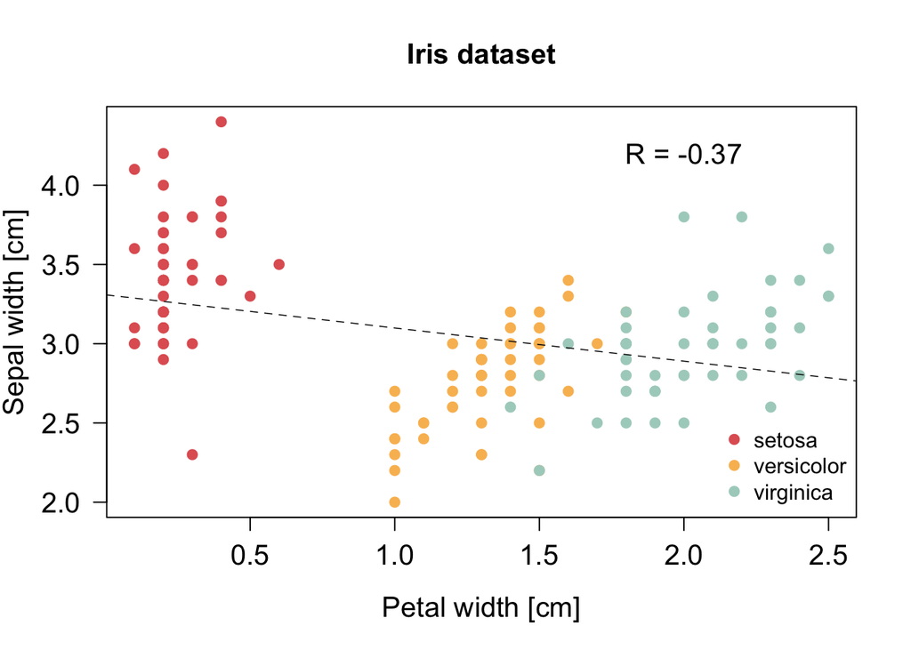

```r
png("Iris_width_plots.png")

plot(iris[,"Petal.Width"],
     iris[,"Sepal.Width"],
     main = "Iris dataset",
     xlab ="Petal width [cm]",
     ylab = "Sepal width [cm]",
     cex.main = 1.3,
     cex.lab = 1.3,
     cex.axis = 1.3,
     las = 1,
     pch = 19,
     col = iris[,"color"])

vFit2 <- lm(Sepal.Width~Petal.Width,
           data=iris)
abline(vFit2,
       col = "gray4",
       lty = 2,
       lwd = 0.8)

R <- round(cor(iris[,"Petal.Width"],
               iris[,"Sepal.Width"]), 2)
text(x = 2, y = 4.2,
     labels = paste0("R = ", R),
     cex = 1.3)

legend("bottomright",
     pch = 19,
     bty = "n",
     col = palette,
     legend = c("setosa", "versicolor", "virginica"))

dev.off()
```